# NewYork_(Y_TAXI)

## **TASK :**

> To perform **Exploratory Data Analysis (EDA)** and gather meaningful insights from the most recent(last month) data series of your choice of Yellow or Green Taxi in New York, USA.  
> The following analysis is for the **Yellow Taxi Trip Records(December - 2019).**

[figure not shown]

## **UNDERSTANDING THE DATASET :**

[figure not shown]

> **The TLC & Data**  
> The New York City **Taxi** and **Limousine Commission** (TLC), created in 1971, is the agency responsible for licensing and regulating New York City's medallion (yellow) taxis, street hail livery (green) taxis, for-hire vehicles (FHVs), commuter vans, and paratrasit vehicles. The TLC collects trip record information for each taxi and for-hire vehicle trip completed by their licensed drivers and vehicles.  
> They receive taxi trip data from the technology service providers (TSPs) that provide electronic metering in each cab, and FHV trip data from the app, community livery, black car, or luxury limousine company, or base, who dispatched the trip.  
> **In each trip record dataset, one row represents a single trip made by a TLC-licensed vehicle.**

## **IMPORTING ALL THE REQUIRED MODULES/LIBRARIES :**

```python
import pandas as pd             # For Data Loading, Manipulation, Cleaning and Analysis.
import numpy as np              # For Mathematical Calculations and Equation Solving.
import datetime                 # For Date-Time Manipulations and Calculations.

# For Data Visualization :
import matplotlib.pyplot as plt
import seaborn as sns
```

## **LOADING THE DATASET :**

```python
fileURL = "https://nyc-tlc.s3.amazonaws.com/trip+data/yellow_tripdata_2019-12.csv"

df = pd.read_csv(fileURL)  # Loading the csv file into a pandas DataFrame.
df.head()                  # Looking at the first 5 entries.
```

|  | VendorID | tpep_pickup_datetime | tpep_dropoff_datetime | passenger_count | trip_distance | RatecodeID | store_and_fwd_flag | PULocationID | DOLocationID | payment_type | fare_amount | extra | mta_tax | tip_amount | tolls_amount | improvement_surcharge | total_amount | congestion_surcharge |
| --- | --- | --- | --- | --- | --- | --- | --- | --- | --- | --- | --- | --- | --- | --- | --- | --- | --- | --- |
| 0 | 1.0 | 2019-12-01 00:26:58 | 2019-12-01 00:41:45 | 1.0 | 4.2 | 1.0 | N | 142 | 116 | 2.0 | 14.5 | 3.0 | 0.5 | 0.0 | 0.0 | 0.3 | 18.3 | 2.5 |
| 1 | 1.0 | 2019-12-01 00:12:08 | 2019-12-01 00:12:14 | 1.0 | 0.0 | 1.0 | N | 145 | 145 | 2.0 | 2.5 | 0.5 | 0.5 | 0.0 | 0.0 | 0.3 | 3.8 | 0.0 |
| 2 | 1.0 | 2019-12-01 00:25:53 | 2019-12-01 00:26:04 | 1.0 | 0.0 | 1.0 | N | 145 | 145 | 2.0 | 2.5 | 0.5 | 0.5 | 0.0 | 0.0 | 0.3 | 3.8 | 0.0 |
| 3 | 1.0 | 2019-12-01 00:12:03 | 2019-12-01 00:33:19 | 2.0 | 9.4 | 1.0 | N | 138 | 25 | 1.0 | 28.5 | 0.5 | 0.5 | 10.0 | 0.0 | 0.3 | 39.8 | 0.0 |
| 4 | 1.0 | 2019-12-01 00:05:27 | 2019-12-01 00:16:32 | 2.0 | 1.6 | 1.0 | N | 161 | 237 | 2.0 | 9.0 | 3.0 | 0.5 | 0.0 | 0.0 | 0.3 | 12.8 | 2.5 |

```python
df.info()                 # A brief information/summary of the DataFrame.
```

```
<class 'pandas.core.frame.DataFrame'>
RangeIndex: 6896317 entries, 0 to 6896316
Data columns (total 18 columns):
 #   Column                 Dtype
---  ------                 -----
 0   VendorID               float64
 1   tpep_pickup_datetime   object
 2   tpep_dropoff_datetime  object
 3   passenger_count        float64
 4   trip_distance          float64
 5   RatecodeID             float64
 6   store_and_fwd_flag     object
 7   PULocationID           int64
 8   DOLocationID           int64
 9   payment_type           float64
 10  fare_amount            float64
 11  extra                  float64
 12  mta_tax                float64
 13  tip_amount             float64
 14  tolls_amount           float64
 15  improvement_surcharge  float64
 16  total_amount           float64
 17  congestion_surcharge   float64
dtypes: float64(13), int64(2), object(3)
memory usage: 947.1+ MB
```

So, We are are having **18 columnns**, out of which **13 are of float type**, **2 are of integer type** and **3 are of object type**.

We are having the data of **68,96,317** Yellow Taxi Trips, in the month of December(2019).

## **UNDERSTANDING THE MEANING OF EACH COLUMN:**

**SHAPE :** 68,96,317 Rows, 18 Columns.

> 1. *VendorID :* A code indicating the TPEP provider that provided the record**(1 = Creative Mobile Technologies, LLC; 2 = VeriFone Inc).**
> 2. *tpep_pickup_datetime :* The date and time when the meter was engaged.
> 3. *tpep_dropoff_datetime :* The date and time when the meter was disengaged.
> 4. *Passenger_count :* The number of passengers in the vehicle. This is a driver-entered value.
> 5. *Trip_distance :* The elapsed trip distance in miles reported by the taximeter.
> 6. *RateCodeID :* The final rate code in effect at the end of the trip**(1 = Standard rate, 2 = JFK, 3 = Newark, 4 = Nassau or Westchester, 5 = Negotiated fare, 6 = Group ride).**
> 7. *Store_and_fwd_flag :* This flag indicates whether the trip record was held in vehicle memory before sending to the vendor, aka “store and forward,” because the vehicle did not have a connection to the server**(Y = store and forward trip, N = not a store and forward trip).**
> 8. *PULocationID :* TLC Taxi Zone in which the taximeter was engaged.
> 9. *DOLocationID :* TLC Taxi Zone in which the taximeter was disengaged.
> 10. *Payment_type :* A numeric code signifying how the passenger paid for the trip**(1 = Credit card, 2 = Cash, 3 = No charge, 4 = Dispute, 5 = Unknown, 6 = Voided trip).**
> 11. *Fare_amount :* The time-and-distance fare calculated by the meter.
> 12. *Extra :* Miscellaneous extras and surcharges. Currently, this only includes the 0.50 and 1 dollars rush hour and overnight charges.
> 13. *MTA_tax :* 0.50 dollars MTA tax that is automatically triggered based on the metered rate in use.
> 14. *Tip_amount :* Tip amount – This field is automatically populated for credit card tips. Cash tips are not included.
> 15. *Tolls_amount :* Total amount of all tolls paid in trip.
> 16. *Improvement_surcharge :* $0.30 improvement surcharge assessed trips at the flag drop. The improvement surcharge began being levied in 2015.
> 17. *Total_amount :* The total amount charged to passengers. Does not include cash tips.

## **DATA CLEANING :**

```python
# Getting some Statistical insights from the numeric type columns :

df.describe()
```

|  | VendorID | passenger_count | trip_distance | RatecodeID | PULocationID | DOLocationID | payment_type | fare_amount | extra | mta_tax | tip_amount | tolls_amount | improvement_surcharge | total_amount | congestion_surcharge |
| --- | --- | --- | --- | --- | --- | --- | --- | --- | --- | --- | --- | --- | --- | --- | --- |
| count | 6.845299e+06 | 6.845299e+06 | 6.896317e+06 | 6.845299e+06 | 6.896317e+06 | 6.896317e+06 | 6.845299e+06 | 6.896317e+06 | 6.896317e+06 | 6.896317e+06 | 6.896317e+06 | 6.896317e+06 | 6.896317e+06 | 6.896317e+06 | 6.896317e+06 |
| mean | 1.666457e+00 | 1.550877e+00 | 2.973421e+00 | 1.065756e+00 | 1.636525e+02 | 1.614892e+02 | 1.298993e+00 | 1.359027e+01 | 1.108518e+00 | 4.924147e-01 | 2.244620e+00 | 3.881238e-01 | 2.979857e-01 | 1.964165e+01 | 2.275278e+00 |
| std | 4.714787e-01 | 1.174330e+00 | 1.643113e+01 | 9.309869e-01 | 6.605758e+01 | 7.033753e+01 | 4.879401e-01 | 1.522692e+02 | 1.259892e+00 | 7.233857e-02 | 2.875127e+00 | 1.715502e+00 | 3.381444e-02 | 1.525236e+02 | 7.359669e-01 |
| min | 1.000000e+00 | 0.000000e+00 | -3.726453e+04 | 1.000000e+00 | 1.000000e+00 | 1.000000e+00 | 1.000000e+00 | -1.472000e+03 | -4.500000e+00 | -5.000000e-01 | -2.008000e+02 | -4.050000e+01 | -3.000000e-01 | -1.472800e+03 | -2.500000e+00 |
| 25% | 1.000000e+00 | 1.000000e+00 | 9.600000e-01 | 1.000000e+00 | 1.250000e+02 | 1.120000e+02 | 1.000000e+00 | 6.500000e+00 | 0.000000e+00 | 5.000000e-01 | 0.000000e+00 | 0.000000e+00 | 3.000000e-01 | 1.130000e+01 | 2.500000e+00 |
| 50% | 2.000000e+00 | 1.000000e+00 | 1.600000e+00 | 1.000000e+00 | 1.620000e+02 | 1.620000e+02 | 1.000000e+00 | 9.500000e+00 | 5.000000e-01 | 5.000000e-01 | 1.920000e+00 | 0.000000e+00 | 3.000000e-01 | 1.480000e+01 | 2.500000e+00 |
| 75% | 2.000000e+00 | 2.000000e+00 | 3.030000e+00 | 1.000000e+00 | 2.330000e+02 | 2.340000e+02 | 2.000000e+00 | 1.543000e+01 | 2.500000e+00 | 5.000000e-01 | 3.000000e+00 | 0.000000e+00 | 3.000000e-01 | 2.135000e+01 | 2.500000e+00 |
| max | 2.000000e+00 | 9.000000e+00 | 1.913018e+04 | 9.900000e+01 | 2.650000e+02 | 2.650000e+02 | 5.000000e+00 | 3.984684e+05 | 9.006000e+01 | 3.300000e+00 | 4.044400e+02 | 6.126600e+02 | 3.000000e-01 | 3.984712e+05 | 3.000000e+00 |

- The column *VendorID* is nominal in nature, with values 1 and 2. This column seems to be fine and valid.
- The column *passenger_count* is a numerical column and we can observe that the minimum value of *passenger_count* is 0, which is not possible. So, We need to rectify this.
- The column *trip_distance* is also a numerical column and we can observe that the minimum value of *trip_distance* is < 0, i.e negative which is not possible. So, We need to rectify this as well.
- The column *RatecodeID* is also a numerical column and we can observe that the maximum value of *RatecodeID* is 99, which is not possible. So, this should also be rectified.
- The columns *PULocationID, DOLocationID* and *payment_type* are all nominal in nature and seems to be fine and valid.
- The columns *fare_amount, extra, mta_tax, tip_amount, tolls_amount, improvement_surcharge, total_amount* and *congestion_surcharge* are all numerical columns, with their least/minimum values < 0, i.e negative which is not possible. So, We need to rectify all these as well.

```python
# For simplicity purpose, We are simply removing all the rows with peculiar/strange/invalid data from our DataFrame.
# Rectifying everything stated above :

df = df[(df['passenger_count'] != 0) & (df['trip_distance'] > 0) & (df['RatecodeID'].isin([1,2,3,4,5,6])) &
        (df['fare_amount'] > 0) & (df['extra'] >= 0) &
        (df['mta_tax'] >= 0) & (df['tolls_amount'] >= 0) &
        (df['improvement_surcharge'] >= 0) & (df['total_amount'] > 0) &
        (df['congestion_surcharge'] >= 0)].copy()
```

```python
# Using df.describe() again :

df.describe()
```

|  | VendorID | passenger_count | trip_distance | RatecodeID | PULocationID | DOLocationID | payment_type | fare_amount | extra | mta_tax | tip_amount | tolls_amount | improvement_surcharge | total_amount | congestion_surcharge |
| --- | --- | --- | --- | --- | --- | --- | --- | --- | --- | --- | --- | --- | --- | --- | --- |
| count | 6.632674e+06 | 6.632674e+06 | 6.632674e+06 | 6.632674e+06 | 6.632674e+06 | 6.632674e+06 | 6.632674e+06 | 6.632674e+06 | 6.632674e+06 | 6.632674e+06 | 6.632674e+06 | 6.632674e+06 | 6.632674e+06 | 6.632674e+06 | 6.632674e+06 |
| mean | 1.679709e+00 | 1.582371e+00 | 2.982477e+00 | 1.045001e+00 | 1.639025e+02 | 1.616172e+02 | 1.290325e+00 | 1.331751e+01 | 1.077492e+00 | 4.977344e-01 | 2.261356e+00 | 3.756524e-01 | 2.999274e-01 | 1.941135e+01 | 2.320947e+00 |
| std | 4.665883e-01 | 1.168533e+00 | 8.387622e+00 | 2.957750e-01 | 6.587797e+01 | 7.017131e+01 | 4.699893e-01 | 1.205312e+01 | 1.239130e+00 | 3.379710e-02 | 2.799209e+00 | 1.678242e+00 | 4.666185e-03 | 1.484181e+01 | 6.446499e-01 |
| min | 1.000000e+00 | 1.000000e+00 | 1.000000e-02 | 1.000000e+00 | 1.000000e+00 | 1.000000e+00 | 1.000000e+00 | 1.000000e-02 | 0.000000e+00 | 0.000000e+00 | 0.000000e+00 | 0.000000e+00 | 0.000000e+00 | 3.100000e-01 | 0.000000e+00 |
| 25% | 1.000000e+00 | 1.000000e+00 | 9.800000e-01 | 1.000000e+00 | 1.250000e+02 | 1.120000e+02 | 1.000000e+00 | 6.500000e+00 | 0.000000e+00 | 5.000000e-01 | 0.000000e+00 | 0.000000e+00 | 3.000000e-01 | 1.130000e+01 | 2.500000e+00 |
| 50% | 2.000000e+00 | 1.000000e+00 | 1.610000e+00 | 1.000000e+00 | 1.620000e+02 | 1.620000e+02 | 1.000000e+00 | 9.500000e+00 | 5.000000e-01 | 5.000000e-01 | 1.960000e+00 | 0.000000e+00 | 3.000000e-01 | 1.480000e+01 | 2.500000e+00 |
| 75% | 2.000000e+00 | 2.000000e+00 | 3.020000e+00 | 1.000000e+00 | 2.340000e+02 | 2.340000e+02 | 2.000000e+00 | 1.500000e+01 | 2.500000e+00 | 5.000000e-01 | 3.000000e+00 | 0.000000e+00 | 3.000000e-01 | 2.100000e+01 | 2.500000e+00 |
| max | 2.000000e+00 | 9.000000e+00 | 1.913018e+04 | 6.000000e+00 | 2.650000e+02 | 2.650000e+02 | 5.000000e+00 | 6.012500e+03 | 9.006000e+01 | 3.300000e+00 | 4.044400e+02 | 6.126600e+02 | 3.000000e-01 | 6.015800e+03 | 3.000000e+00 |

```python
df['trip_distance'].nlargest(10)
```

```
704581     19130.18
5835474      363.13
2121568      323.81
6394756      300.80
3531774      248.60
1164308      234.50
1466028      206.72
5474390      173.50
6241077      171.05
5772761      163.30
Name: trip_distance, dtype: float64
```

We can clearly observe, that the **largest trip_distance is very large and seems to be very strange compared to rest of the trips**. So, this **might have been entered by mistake** and hence we will delete/drop this trip record from our DataFrame.

```python
# We can clearly see that the label of the row, with the largest trip_distance is 704581.
df.drop(704581, inplace = True)   # Deleting the row, with label 704581.

df.describe()
```

|  | VendorID | passenger_count | trip_distance | RatecodeID | PULocationID | DOLocationID | payment_type | fare_amount | extra | mta_tax | tip_amount | tolls_amount | improvement_surcharge | total_amount | congestion_surcharge |
| --- | --- | --- | --- | --- | --- | --- | --- | --- | --- | --- | --- | --- | --- | --- | --- |
| count | 6.632673e+06 | 6.632673e+06 | 6.632673e+06 | 6.632673e+06 | 6.632673e+06 | 6.632673e+06 | 6.632673e+06 | 6.632673e+06 | 6.632673e+06 | 6.632673e+06 | 6.632673e+06 | 6.632673e+06 | 6.632673e+06 | 6.632673e+06 | 6.632673e+06 |
| mean | 1.679709e+00 | 1.582371e+00 | 2.979593e+00 | 1.045000e+00 | 1.639025e+02 | 1.616172e+02 | 1.290325e+00 | 1.331751e+01 | 1.077492e+00 | 4.977345e-01 | 2.261356e+00 | 3.756524e-01 | 2.999275e-01 | 1.941135e+01 | 2.320947e+00 |
| std | 4.665883e-01 | 1.168533e+00 | 3.897882e+00 | 2.957711e-01 | 6.587797e+01 | 7.017132e+01 | 4.699893e-01 | 1.205312e+01 | 1.239130e+00 | 3.379655e-02 | 2.799209e+00 | 1.678242e+00 | 4.664732e-03 | 1.484181e+01 | 6.446493e-01 |
| min | 1.000000e+00 | 1.000000e+00 | 1.000000e-02 | 1.000000e+00 | 1.000000e+00 | 1.000000e+00 | 1.000000e+00 | 1.000000e-02 | 0.000000e+00 | 0.000000e+00 | 0.000000e+00 | 0.000000e+00 | 0.000000e+00 | 3.100000e-01 | 0.000000e+00 |
| 25% | 1.000000e+00 | 1.000000e+00 | 9.800000e-01 | 1.000000e+00 | 1.250000e+02 | 1.120000e+02 | 1.000000e+00 | 6.500000e+00 | 0.000000e+00 | 5.000000e-01 | 0.000000e+00 | 0.000000e+00 | 3.000000e-01 | 1.130000e+01 | 2.500000e+00 |
| 50% | 2.000000e+00 | 1.000000e+00 | 1.610000e+00 | 1.000000e+00 | 1.620000e+02 | 1.620000e+02 | 1.000000e+00 | 9.500000e+00 | 5.000000e-01 | 5.000000e-01 | 1.960000e+00 | 0.000000e+00 | 3.000000e-01 | 1.480000e+01 | 2.500000e+00 |
| 75% | 2.000000e+00 | 2.000000e+00 | 3.020000e+00 | 1.000000e+00 | 2.340000e+02 | 2.340000e+02 | 2.000000e+00 | 1.500000e+01 | 2.500000e+00 | 5.000000e-01 | 3.000000e+00 | 0.000000e+00 | 3.000000e-01 | 2.100000e+01 | 2.500000e+00 |
| max | 2.000000e+00 | 9.000000e+00 | 3.631300e+02 | 6.000000e+00 | 2.650000e+02 | 2.650000e+02 | 5.000000e+00 | 6.012500e+03 | 9.006000e+01 | 3.300000e+00 | 4.044400e+02 | 6.126600e+02 | 3.000000e-01 | 6.015800e+03 | 3.000000e+00 |

```python
# Looking at the number of Nulls/NaNs in each column :

df.isnull().sum()
```

```
VendorID                 0
tpep_pickup_datetime     0
tpep_dropoff_datetime    0
passenger_count          0
trip_distance            0
RatecodeID               0
store_and_fwd_flag       0
PULocationID             0
DOLocationID             0
payment_type             0
fare_amount              0
extra                    0
mta_tax                  0
tip_amount               0
tolls_amount             0
improvement_surcharge    0
total_amount             0
congestion_surcharge     0
dtype: int64
```

So, We can clearly see that we are not having any Nulls/NaNs now.

*Now, We can safely say that all the numerical columns, seems to be fine and valid.*

```python
# Reseting all the row indices :
df.reset_index(drop = True, inplace = True)
```

```python
# Using .describe() again :

df.describe()
```

|  | VendorID | passenger_count | trip_distance | RatecodeID | PULocationID | DOLocationID | payment_type | fare_amount | extra | mta_tax | tip_amount | tolls_amount | improvement_surcharge | total_amount | congestion_surcharge |
| --- | --- | --- | --- | --- | --- | --- | --- | --- | --- | --- | --- | --- | --- | --- | --- |
| count | 6.632673e+06 | 6.632673e+06 | 6.632673e+06 | 6.632673e+06 | 6.632673e+06 | 6.632673e+06 | 6.632673e+06 | 6.632673e+06 | 6.632673e+06 | 6.632673e+06 | 6.632673e+06 | 6.632673e+06 | 6.632673e+06 | 6.632673e+06 | 6.632673e+06 |
| mean | 1.679709e+00 | 1.582371e+00 | 2.979593e+00 | 1.045000e+00 | 1.639025e+02 | 1.616172e+02 | 1.290325e+00 | 1.331751e+01 | 1.077492e+00 | 4.977345e-01 | 2.261356e+00 | 3.756524e-01 | 2.999275e-01 | 1.941135e+01 | 2.320947e+00 |
| std | 4.665883e-01 | 1.168533e+00 | 3.897882e+00 | 2.957711e-01 | 6.587797e+01 | 7.017132e+01 | 4.699893e-01 | 1.205312e+01 | 1.239130e+00 | 3.379655e-02 | 2.799209e+00 | 1.678242e+00 | 4.664732e-03 | 1.484181e+01 | 6.446493e-01 |
| min | 1.000000e+00 | 1.000000e+00 | 1.000000e-02 | 1.000000e+00 | 1.000000e+00 | 1.000000e+00 | 1.000000e+00 | 1.000000e-02 | 0.000000e+00 | 0.000000e+00 | 0.000000e+00 | 0.000000e+00 | 0.000000e+00 | 3.100000e-01 | 0.000000e+00 |
| 25% | 1.000000e+00 | 1.000000e+00 | 9.800000e-01 | 1.000000e+00 | 1.250000e+02 | 1.120000e+02 | 1.000000e+00 | 6.500000e+00 | 0.000000e+00 | 5.000000e-01 | 0.000000e+00 | 0.000000e+00 | 3.000000e-01 | 1.130000e+01 | 2.500000e+00 |
| 50% | 2.000000e+00 | 1.000000e+00 | 1.610000e+00 | 1.000000e+00 | 1.620000e+02 | 1.620000e+02 | 1.000000e+00 | 9.500000e+00 | 5.000000e-01 | 5.000000e-01 | 1.960000e+00 | 0.000000e+00 | 3.000000e-01 | 1.480000e+01 | 2.500000e+00 |
| 75% | 2.000000e+00 | 2.000000e+00 | 3.020000e+00 | 1.000000e+00 | 2.340000e+02 | 2.340000e+02 | 2.000000e+00 | 1.500000e+01 | 2.500000e+00 | 5.000000e-01 | 3.000000e+00 | 0.000000e+00 | 3.000000e-01 | 2.100000e+01 | 2.500000e+00 |
| max | 2.000000e+00 | 9.000000e+00 | 3.631300e+02 | 6.000000e+00 | 2.650000e+02 | 2.650000e+02 | 5.000000e+00 | 6.012500e+03 | 9.006000e+01 | 3.300000e+00 | 4.044400e+02 | 6.126600e+02 | 3.000000e-01 | 6.015800e+03 | 3.000000e+00 |

```python
# Looking at the shape of the cleaned DataFrame :

df.shape
```

```
(6632673, 18)
```

```python
# So, After doing all the cleaning, We can see that our resultant DataFrame has 6632673 rows and 18 columns.
# The cleaned DataFrame looks like :

df.head(10)
```

|  | VendorID | tpep_pickup_datetime | tpep_dropoff_datetime | passenger_count | trip_distance | RatecodeID | store_and_fwd_flag | PULocationID | DOLocationID | payment_type | fare_amount | extra | mta_tax | tip_amount | tolls_amount | improvement_surcharge | total_amount | congestion_surcharge |
| --- | --- | --- | --- | --- | --- | --- | --- | --- | --- | --- | --- | --- | --- | --- | --- | --- | --- | --- |
| 0 | 1.0 | 2019-12-01 00:26:58 | 2019-12-01 00:41:45 | 1.0 | 4.20 | 1.0 | N | 142 | 116 | 2.0 | 14.5 | 3.0 | 0.5 | 0.00 | 0.0 | 0.3 | 18.30 | 2.5 |
| 1 | 1.0 | 2019-12-01 00:12:03 | 2019-12-01 00:33:19 | 2.0 | 9.40 | 1.0 | N | 138 | 25 | 1.0 | 28.5 | 0.5 | 0.5 | 10.00 | 0.0 | 0.3 | 39.80 | 0.0 |
| 2 | 1.0 | 2019-12-01 00:05:27 | 2019-12-01 00:16:32 | 2.0 | 1.60 | 1.0 | N | 161 | 237 | 2.0 | 9.0 | 3.0 | 0.5 | 0.00 | 0.0 | 0.3 | 12.80 | 2.5 |
| 3 | 1.0 | 2019-12-01 00:58:51 | 2019-12-01 01:08:37 | 2.0 | 1.00 | 1.0 | N | 161 | 230 | 2.0 | 6.5 | 3.0 | 0.5 | 0.00 | 0.0 | 0.3 | 10.30 | 2.5 |
| 4 | 1.0 | 2019-12-01 00:19:48 | 2019-12-01 00:24:18 | 1.0 | 0.90 | 1.0 | N | 148 | 4 | 1.0 | 5.5 | 3.0 | 0.5 | 1.85 | 0.0 | 0.3 | 11.15 | 2.5 |
| 5 | 1.0 | 2019-12-01 00:36:16 | 2019-12-01 00:53:42 | 3.0 | 5.50 | 1.0 | N | 79 | 226 | 1.0 | 18.0 | 3.0 | 0.5 | 4.35 | 0.0 | 0.3 | 26.15 | 2.5 |
| 6 | 2.0 | 2019-11-30 23:54:45 | 2019-12-01 00:09:57 | 1.0 | 2.12 | 1.0 | N | 234 | 230 | 2.0 | 12.0 | 0.5 | 0.5 | 0.00 | 0.0 | 0.3 | 15.80 | 2.5 |
| 7 | 2.0 | 2019-12-01 00:39:43 | 2019-12-01 00:52:06 | 1.0 | 1.15 | 1.0 | N | 186 | 48 | 2.0 | 9.0 | 0.5 | 0.5 | 0.00 | 0.0 | 0.3 | 12.80 | 2.5 |
| 8 | 2.0 | 2019-12-01 00:43:02 | 2019-12-01 01:11:18 | 1.0 | 13.07 | 1.0 | N | 41 | 51 | 2.0 | 38.5 | 0.5 | 0.5 | 0.00 | 0.0 | 0.3 | 39.80 | 0.0 |
| 9 | 1.0 | 2019-12-01 00:57:16 | 2019-12-01 01:19:32 | 1.0 | 3.30 | 1.0 | N | 230 | 230 | 2.0 | 15.0 | 3.0 | 0.5 | 0.00 | 0.0 | 0.3 | 18.80 | 2.5 |

## **EXPLORATORY DATA ANALYSIS :**

We can see that the columns *tpep_pickup_datetime* and *tpep_dropoff_datetime* are of type object. So, We are converting them into **'datetime'** type for better analysis and understanding.

So, We are creating 2 columns named *pickup_datetime* and *dropoff_datetime* (of type datetime) from the 2 columns *tpep_pickup_datetime*, *tpep_dropoff_datetime* (of type object).

```python
df['pickup_datetime'] = pd.to_datetime(df['tpep_pickup_datetime'])
df['dropoff_datetime'] = pd.to_datetime(df['tpep_dropoff_datetime'])

# Now we can safely delete/drop the previous 2 columns named 'tpep_pickup_datetime' and 'tpep_dropoff_datetime'.
df.drop('tpep_pickup_datetime', axis = 1, inplace = True)
df.drop('tpep_dropoff_datetime', axis = 1, inplace = True)

df.head()
```

|  | VendorID | passenger_count | trip_distance | RatecodeID | store_and_fwd_flag | PULocationID | DOLocationID | payment_type | fare_amount | extra | mta_tax | tip_amount | tolls_amount | improvement_surcharge | total_amount | congestion_surcharge | pickup_datetime | dropoff_datetime |
| --- | --- | --- | --- | --- | --- | --- | --- | --- | --- | --- | --- | --- | --- | --- | --- | --- | --- | --- |
| 0 | 1.0 | 1.0 | 4.2 | 1.0 | N | 142 | 116 | 2.0 | 14.5 | 3.0 | 0.5 | 0.00 | 0.0 | 0.3 | 18.30 | 2.5 | 2019-12-01 00:26:58 | 2019-12-01 00:41:45 |
| 1 | 1.0 | 2.0 | 9.4 | 1.0 | N | 138 | 25 | 1.0 | 28.5 | 0.5 | 0.5 | 10.00 | 0.0 | 0.3 | 39.80 | 0.0 | 2019-12-01 00:12:03 | 2019-12-01 00:33:19 |
| 2 | 1.0 | 2.0 | 1.6 | 1.0 | N | 161 | 237 | 2.0 | 9.0 | 3.0 | 0.5 | 0.00 | 0.0 | 0.3 | 12.80 | 2.5 | 2019-12-01 00:05:27 | 2019-12-01 00:16:32 |
| 3 | 1.0 | 2.0 | 1.0 | 1.0 | N | 161 | 230 | 2.0 | 6.5 | 3.0 | 0.5 | 0.00 | 0.0 | 0.3 | 10.30 | 2.5 | 2019-12-01 00:58:51 | 2019-12-01 01:08:37 |
| 4 | 1.0 | 1.0 | 0.9 | 1.0 | N | 148 | 4 | 1.0 | 5.5 | 3.0 | 0.5 | 1.85 | 0.0 | 0.3 | 11.15 | 2.5 | 2019-12-01 00:19:48 | 2019-12-01 00:24:18 |

```python
# Looking at the data types of all the columns, once again :

df.dtypes
```

```
VendorID                        float64
passenger_count                 float64
trip_distance                   float64
RatecodeID                      float64
store_and_fwd_flag               object
PULocationID                      int64
DOLocationID                      int64
payment_type                    float64
fare_amount                     float64
extra                           float64
mta_tax                         float64
tip_amount                      float64
tolls_amount                    float64
improvement_surcharge           float64
total_amount                    float64
congestion_surcharge            float64
pickup_datetime          datetime64[ns]
dropoff_datetime         datetime64[ns]
dtype: object
```

### **ANALYZING THE SIGNIFICANCE OF EACH COLUMN :**

#### **passenger_count :**

```python
# A Series of all the possible values that the column 'passenger_count' can take and their corresponding frequencies.

df['passenger_count'].value_counts()
```

```
1.0    4714919
2.0    1064250
3.0     300109
5.0     243458
4.0     162689
6.0     147204
7.0         26
8.0         12
9.0          6
Name: passenger_count, dtype: int64
```

```python
values = df['passenger_count'].value_counts().index
# An array of all the possible values, the column 'passenger_count' can take.

frequencies = df['passenger_count'].value_counts().values
# An array of the frequencies of all the possible values, the column 'passenger_count' can take.
```

```
Passenger Count : 1.0 (71.09%)
Passenger Count : 2.0 (16.05%)
Passenger Count : 3.0 (4.52%)
Passenger Count : 5.0 (3.67%)
Passenger Count : 4.0 (2.45%)
Passenger Count : 6.0 (2.22%)
Passenger Count : 7.0 (0.00%)
Passenger Count : 8.0 (0.00%)
Passenger Count : 9.0 (0.00%)
```

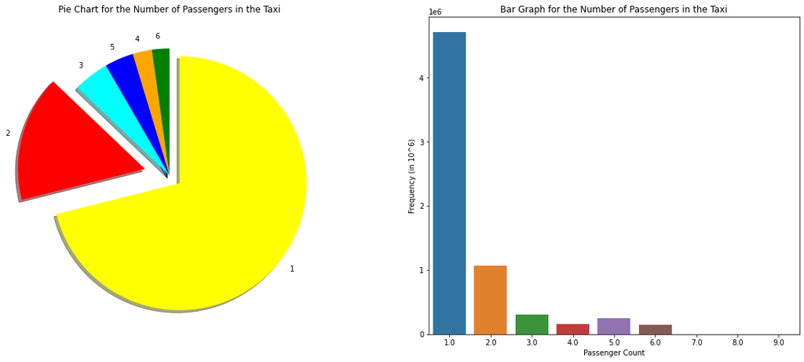

```python
fig = plt.figure(figsize = (20,8))
fig.add_subplot(1,2,1)

# Plotting a Pie Chart for the passenger_count in the Taxi.
colors = ['yellow','red','cyan','blue','orange','green','pink','indigo','grey']
explode = [0.1,0.2,0,0,0,0,0,0,0]
labels = [1,2,3,5,4,6,'','','']
plt.pie(frequencies,colors = colors,explode = explode,labels = labels,counterclock = False,startangle = 90,shadow = True)
plt.title("Pie Chart for the Number of Passengers in the Taxi")

# Plotting a Bar Graph for the passenger_count in the Taxi.
fig.add_subplot(1,2,2)
sns.barplot(values, frequencies)
plt.xlabel("Passenger Count")
plt.ylabel("Frequency (in 10^6)")
plt.title("Bar Graph for the Number of Passengers in the Taxi")

# Percentage Share of each possible value of passenger_count(IN DESCENDING ORDER & UPTO 2 decimal places) :
total = sum(frequencies)
for i in range(len(values)):
  print("Passenger Count :", values[i], '(' + '%.2f'%((frequencies[i]/total)*100) + '%)' )

print('\n\n')
plt.show()
```

So, We can observe that **87.14%** of the total trips have either **1 or 2 passengers**, and the percentage share/proportion of the trips with **passenger_count >= 7 is almost 0%.** Hence we have a total of only **6 pies and 6 bars** in the PieChart and the BarGraph respectively(as the percentage share/proportion of passenger_count >= 7 is almost 0%).

**OBSERVATIONS :**

*Hence, we can infer that **most of the times(approximately 87%), a taxi would comprise of either 1 or 2 passengers, with the chances of 1 passenger being more(71.09% compared to 16.05%)**. The **chances of large group of people travelling together are rare**.*

#### **pickup_datetime & dropoff_datetime :**

```python
# Looking at the number of unique entries in the columns, 'pickup_datetime' and 'dropoff_datetime':

print(df['pickup_datetime'].nunique(), df['dropoff_datetime'].nunique())
```

```
2158118 2160561
```

So, We are having a lot of unique entries in these 2 columns, approximately 21 lakhs.

So, We are going to convert these dates into **"days of week"**, so that better analysis and visualization can be achieved.

```python
# So, we are adding 2 new columns named "pickup_day" and "dropoff_day" in the DataFrame as :

df['pickup_day'] = df['pickup_datetime'].dt.day_name()
df['dropoff_day'] = df['dropoff_datetime'].dt.day_name()
df.head()

# Observe the 2 new columns, at the end.
```

|  | VendorID | passenger_count | trip_distance | RatecodeID | store_and_fwd_flag | PULocationID | DOLocationID | payment_type | fare_amount | extra | mta_tax | tip_amount | tolls_amount | improvement_surcharge | total_amount | congestion_surcharge | pickup_datetime | dropoff_datetime | pickup_day | dropoff_day |
| --- | --- | --- | --- | --- | --- | --- | --- | --- | --- | --- | --- | --- | --- | --- | --- | --- | --- | --- | --- | --- |
| 0 | 1.0 | 1.0 | 4.2 | 1.0 | N | 142 | 116 | 2.0 | 14.5 | 3.0 | 0.5 | 0.00 | 0.0 | 0.3 | 18.30 | 2.5 | 2019-12-01 00:26:58 | 2019-12-01 00:41:45 | Sunday | Sunday |
| 1 | 1.0 | 2.0 | 9.4 | 1.0 | N | 138 | 25 | 1.0 | 28.5 | 0.5 | 0.5 | 10.00 | 0.0 | 0.3 | 39.80 | 0.0 | 2019-12-01 00:12:03 | 2019-12-01 00:33:19 | Sunday | Sunday |
| 2 | 1.0 | 2.0 | 1.6 | 1.0 | N | 161 | 237 | 2.0 | 9.0 | 3.0 | 0.5 | 0.00 | 0.0 | 0.3 | 12.80 | 2.5 | 2019-12-01 00:05:27 | 2019-12-01 00:16:32 | Sunday | Sunday |
| 3 | 1.0 | 2.0 | 1.0 | 1.0 | N | 161 | 230 | 2.0 | 6.5 | 3.0 | 0.5 | 0.00 | 0.0 | 0.3 | 10.30 | 2.5 | 2019-12-01 00:58:51 | 2019-12-01 01:08:37 | Sunday | Sunday |
| 4 | 1.0 | 1.0 | 0.9 | 1.0 | N | 148 | 4 | 1.0 | 5.5 | 3.0 | 0.5 | 1.85 | 0.0 | 0.3 | 11.15 | 2.5 | 2019-12-01 00:19:48 | 2019-12-01 00:24:18 | Sunday | Sunday |

```python
# Getting the frequency distribution of each 'pickup_day' and 'dropoff_day'.

print(df['pickup_day'].value_counts(),'\n\n')
print(df['dropoff_day'].value_counts())
```

```
Tuesday      1043831
Monday        984451
Friday        958517
Thursday      947063
Sunday        946386
Saturday      898604
Wednesday     853821
Name: pickup_day, dtype: int64


Tuesday      1042746
Monday        983697
Friday        956607
Sunday        953355
Thursday      944349
Saturday      898444
Wednesday     853475
Name: dropoff_day, dtype: int64
```

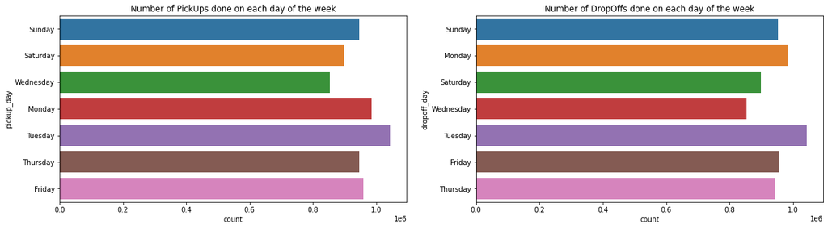

```python
# Graphical Representation of the same :

fig, ax = plt.subplots(nrows = 1, ncols = 2, figsize = (20, 5))

ax[0].set_title('Number of PickUps done on each day of the week')
sns.countplot(y = 'pickup_day', data = df, ax = ax[0])

ax[1].set_title('Number of DropOffs done on each day of the week')
sns.countplot(y = 'dropoff_day', data = df, ax = ax[1])

plt.show()
```

We can clearly observe that most of the trips, were taken on **Tuesdays and Mondays(Starting Days of the Week)** and lesser on **Weekends(Saturdays and Sundays)**. Similar to what one expects.

But an interesting observation, here is that the least trips were made on **Wednesdays**.

If we look at the calendar of December 2019, We can observe that **25th December(The Christmas)** is on Wednesday. Perhaps this could be the reason, why least number of trips were made on Wednesdays **(As the number of trips on Christmas would have been very less)**.

*AN INTERESTING OBSERVATION :*

*We can clearly observe that the **number of drop-offs on Sundays is greater than the number of pick-ups on Sundays.** Hence one can conclude that a **decent number of trips are made during Saturday nights i.e Perhaps the people prefer night-outs during Saturday nights**.*

The pickup and dropoff time part is represented by hours, minutes and seconds which is difficult for analysis. So, We will divide all the times into 4 TimeZones as : **Morning (4 hrs to 10 hrs)/(4:00 AM to 10:00 AM)** , **Midday (10 hrs to 16 hrs)/(10:00 AM to 4:00 PM)** , **Evening (16 hrs to 22 hrs)/(4:00 PM to 10:00 PM)** and **Late night (22 hrs to 04 hrs)/(10:00 PM to 4:00 AM).**

```python
def giveTimeZone(time):     # A function that takes in the time(datetime.time()) and performs the above job :

  if time > datetime.time(4,0,0) and time <= datetime.time(10,0,0):
    return "Morning"
  elif time > datetime.time(10,0,0) and time <= datetime.time(16,0,0):
    return "Mid Day"
  elif time > datetime.time(16,0,0) and time <= datetime.time(22,0,0):
    return "Evening"
  else:
    return "Late Night"
```

```python
# Adding 2 new columns 'pickup_timezone' and 'dropoff_timezone' in the DataFrame as :

df['pickup_timezone'] = df['pickup_datetime'].apply(lambda DateTime : giveTimeZone(datetime.datetime.strptime(str(DateTime), "%Y-%m-%d %H:%M:%S").time()) )
```

```python
df['dropoff_timezone'] = df['dropoff_datetime'].apply(lambda DateTime : giveTimeZone(datetime.datetime.strptime(str(DateTime), "%Y-%m-%d %H:%M:%S").time()) )
```

In the above 2 lines, We have called the above function **(giveTimeZone(), which expects a datetime.time() object)** for each and every value of the *pickup_datetime* and *dropoff_datetime* columns.

But the datatype of *pickup_datetime* and *dropoff_datetime* columns is **datetime** while the function giveTimeZone expects a **datetime.time()** input. Hence we have used the **datetime.datetime.strptime().time()** method to **extract only the time part** from these 2 columns.

We have used the **lambda keyword**, to call the giveTimeZone() function. **"%Y-%m-%d %H:%M:%S"** is the format in which the entries are present in the 2 columns*(pickup_datetime* and *dropoff_datetime)*.

```python
# Observe the 2 new columns, at the end :

df.head()
```

|  | VendorID | passenger_count | trip_distance | RatecodeID | store_and_fwd_flag | PULocationID | DOLocationID | payment_type | fare_amount | extra | mta_tax | tip_amount | tolls_amount | improvement_surcharge | total_amount | congestion_surcharge | pickup_datetime | dropoff_datetime | pickup_day | dropoff_day | pickup_timezone | dropoff_timezone |
| --- | --- | --- | --- | --- | --- | --- | --- | --- | --- | --- | --- | --- | --- | --- | --- | --- | --- | --- | --- | --- | --- | --- |
| 0 | 1.0 | 1.0 | 4.2 | 1.0 | N | 142 | 116 | 2.0 | 14.5 | 3.0 | 0.5 | 0.00 | 0.0 | 0.3 | 18.30 | 2.5 | 2019-12-01 00:26:58 | 2019-12-01 00:41:45 | Sunday | Sunday | Late Night | Late Night |
| 1 | 1.0 | 2.0 | 9.4 | 1.0 | N | 138 | 25 | 1.0 | 28.5 | 0.5 | 0.5 | 10.00 | 0.0 | 0.3 | 39.80 | 0.0 | 2019-12-01 00:12:03 | 2019-12-01 00:33:19 | Sunday | Sunday | Late Night | Late Night |
| 2 | 1.0 | 2.0 | 1.6 | 1.0 | N | 161 | 237 | 2.0 | 9.0 | 3.0 | 0.5 | 0.00 | 0.0 | 0.3 | 12.80 | 2.5 | 2019-12-01 00:05:27 | 2019-12-01 00:16:32 | Sunday | Sunday | Late Night | Late Night |
| 3 | 1.0 | 2.0 | 1.0 | 1.0 | N | 161 | 230 | 2.0 | 6.5 | 3.0 | 0.5 | 0.00 | 0.0 | 0.3 | 10.30 | 2.5 | 2019-12-01 00:58:51 | 2019-12-01 01:08:37 | Sunday | Sunday | Late Night | Late Night |
| 4 | 1.0 | 1.0 | 0.9 | 1.0 | N | 148 | 4 | 1.0 | 5.5 | 3.0 | 0.5 | 1.85 | 0.0 | 0.3 | 11.15 | 2.5 | 2019-12-01 00:19:48 | 2019-12-01 00:24:18 | Sunday | Sunday | Late Night | Late Night |

```python
# Getting the frequency distribution of each 'pickup_timezone' and 'dropoff_timezone'.

print(df['pickup_timezone'].value_counts(),'\n\n')
print(df['dropoff_timezone'].value_counts())
```

```
Evening       2309712
Mid Day       2159472
Late Night    1139407
Morning       1024082
Name: pickup_timezone, dtype: int64


Evening       2329473
Mid Day       2121343
Late Night    1217062
Morning        964795
Name: dropoff_timezone, dtype: int64
```

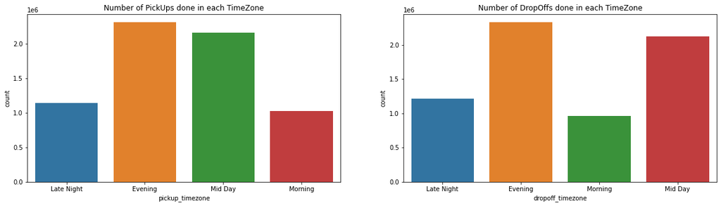

```python
# Graphical representation of the same :

fig, ax = plt.subplots(nrows = 1, ncols = 2, figsize = (20, 5))

ax[0].set_title('Number of PickUps done in each TimeZone')
sns.countplot(x = 'pickup_timezone', data = df, ax = ax[0])

ax[1].set_title('Number of DropOffs done in each TimeZone')
sns.countplot(x = 'dropoff_timezone', data = df, ax = ax[1])

plt.show()
```

**OBSERVATIONS :**

*So, We can clearly observe that the **maximum number of pick-ups and drop-offs occured in the Evenings(4:00 PM to 10:00 PM) and Mid Days(10:00 AM to 04:00 PM)** and the **least occured in Mornings(4:00 AM to 10:00 AM)**.*

*Similar to what one expects.*

```python
# Now, We are going to add another 2 columns named 'pickup_hour' and 'dropoff_hour', depicting the hour of the day in which the pickup or the dropoff occured.

df['pickup_hour'] = df['pickup_datetime'].dt.hour
df['dropoff_hour'] = df['dropoff_datetime'].dt.hour

df.head()
# Observe the 2 new columns, at the end.
```

|  | VendorID | passenger_count | trip_distance | RatecodeID | store_and_fwd_flag | PULocationID | DOLocationID | payment_type | fare_amount | extra | mta_tax | tip_amount | tolls_amount | improvement_surcharge | total_amount | congestion_surcharge | pickup_datetime | dropoff_datetime | pickup_day | dropoff_day | pickup_timezone | dropoff_timezone | pickup_hour | dropoff_hour |
| --- | --- | --- | --- | --- | --- | --- | --- | --- | --- | --- | --- | --- | --- | --- | --- | --- | --- | --- | --- | --- | --- | --- | --- | --- |
| 0 | 1.0 | 1.0 | 4.2 | 1.0 | N | 142 | 116 | 2.0 | 14.5 | 3.0 | 0.5 | 0.00 | 0.0 | 0.3 | 18.30 | 2.5 | 2019-12-01 00:26:58 | 2019-12-01 00:41:45 | Sunday | Sunday | Late Night | Late Night | 0 | 0 |
| 1 | 1.0 | 2.0 | 9.4 | 1.0 | N | 138 | 25 | 1.0 | 28.5 | 0.5 | 0.5 | 10.00 | 0.0 | 0.3 | 39.80 | 0.0 | 2019-12-01 00:12:03 | 2019-12-01 00:33:19 | Sunday | Sunday | Late Night | Late Night | 0 | 0 |
| 2 | 1.0 | 2.0 | 1.6 | 1.0 | N | 161 | 237 | 2.0 | 9.0 | 3.0 | 0.5 | 0.00 | 0.0 | 0.3 | 12.80 | 2.5 | 2019-12-01 00:05:27 | 2019-12-01 00:16:32 | Sunday | Sunday | Late Night | Late Night | 0 | 0 |
| 3 | 1.0 | 2.0 | 1.0 | 1.0 | N | 161 | 230 | 2.0 | 6.5 | 3.0 | 0.5 | 0.00 | 0.0 | 0.3 | 10.30 | 2.5 | 2019-12-01 00:58:51 | 2019-12-01 01:08:37 | Sunday | Sunday | Late Night | Late Night | 0 | 1 |
| 4 | 1.0 | 1.0 | 0.9 | 1.0 | N | 148 | 4 | 1.0 | 5.5 | 3.0 | 0.5 | 1.85 | 0.0 | 0.3 | 11.15 | 2.5 | 2019-12-01 00:19:48 | 2019-12-01 00:24:18 | Sunday | Sunday | Late Night | Late Night | 0 | 0 |

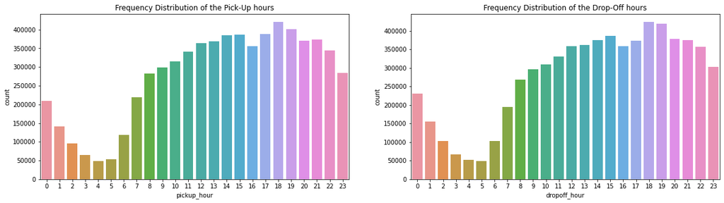

```python
# Bar Graph, representing the frequecy distribution of the 'pickup_hour' and 'dropoff_hour' :

fig, ax = plt.subplots(nrows = 1, ncols = 2, figsize = (20,5))

ax[0].set_title("Frequency Distribution of the Pick-Up hours")
sns.countplot(x = 'pickup_hour', data = df, ax = ax[0])

ax[1].set_title("Frequency Distribution of the Drop-Off hours")
sns.countplot(x = 'dropoff_hour', data = df, ax = ax[1])

plt.show()
```

The above plot seems to be in accordance with the plot **Frequency distribution of the 4 TimeZones**.

**OBSERVATIONS :**

- *The least number of trips were made during **(00 - 07 hours)/(12:00 AM to 7:00 AM)**.*
- *There seems to be a **significant rise/increase in the number of trips from (07 - 14 hours)/(7:00 AM to 2:00 PM)**.*
- *The **number of trips during the peak-hours (17 - 19 hours)/(5:00 PM to 7:00 PM) are significantly high**.*
- *There seems to be a **significant fall/decrease in the number of trips from (21 - 04 hours)/(9:00 PM to 4:00 AM)**.*

#### **VendorID :**

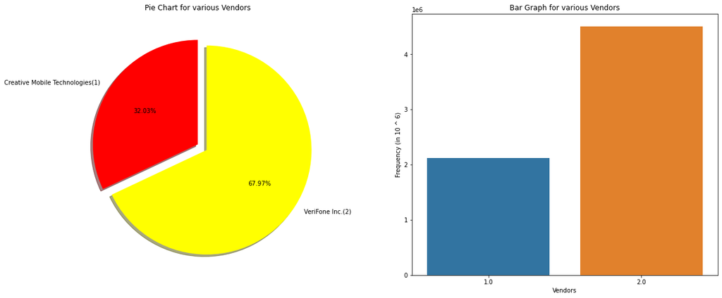

```python
# Frequency Distribution of VendorId :

values = df['VendorID'].value_counts().index
frequencies = df['VendorID'].value_counts().values

# Plotting a PieChart for the various Vendors :
fig = plt.figure(figsize = (20,8))
fig.add_subplot(1,2,1)
plt.title('Pie Chart for various Vendors')
colors = ['yellow','red']
labels = ['VeriFone Inc.(2)', 'Creative Mobile Technologies(1)']
explode = [0.1, 0]
plt.pie(frequencies, colors = colors, labels = labels, explode = explode, autopct = '%.2f%%', counterclock = False, startangle = 90, shadow = True)

# Plotting a BarGraph for the various Vendors :
fig.add_subplot(1,2,2)
plt.title('Bar Graph for various Vendors')
sns.barplot(values, frequencies)
plt.xlabel("Vendors")
plt.ylabel("Frequency (in 10 ^ 6)")

plt.show()
```

**OBSEVATIONS :**

- *Approximately **(2/3)rd/(67.97)%** of the trip records are provided by **Verifone Inc.** while the rest **(1/3)rd/(32.03)%** are provided by **Creative Mobile Technologies**.*

#### **RateCodeID :**

```
RatecodeID : 1.0 (96.78%)
RatecodeID : 2.0 (2.59%)
RatecodeID : 5.0 (0.29%)
RatecodeID : 3.0 (0.26%)
RatecodeID : 4.0 (0.08%)
RatecodeID : 6.0 (0.00%)
```

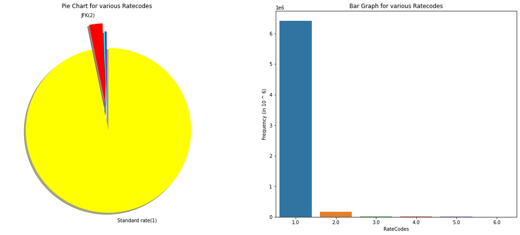

```python
# Frequency Distribution of RatecodeID :

values = df['RatecodeID'].value_counts().index
frequencies = df['RatecodeID'].value_counts().values

# Plotting a PieChart for the various Ratecodes :
fig = plt.figure(figsize = (20,8))
fig.add_subplot(1,2,1)
plt.title('Pie Chart for various Ratecodes')
colors = ['yellow','red', 'cyan', 'blue', 'violet', 'green']
explode = [0.2, 0.1, 0, 0, 0, 0]
labels = ['Standard rate(1)','JFK(2)','','','','']
plt.pie(frequencies, colors = colors, labels = labels, explode = explode, counterclock = False, startangle = 90, shadow = True)

# Plotting a BarGraph for the various Ratecodes :
fig.add_subplot(1,2,2)
plt.title('Bar Graph for various Ratecodes')
sns.barplot(values, frequencies)
plt.xlabel("RateCodes")
plt.ylabel("Frequency (in 10 ^ 6)")

# Percentage Share of each possible value of RatecodeID(IN DESCENDING ORDER & UPTO 2 decimal places) :
total = sum(frequencies)
for i in range(len(values)):
  print("RatecodeID :", values[i], '(' + '%.2f'%((frequencies[i]/total)*100) + '%)' )

print('\n\n')
plt.show()
```

**OBSERVATIONS :**

- *For most of the trips**(approximately 97%), the Standard rate code(1) is in effect at the end of the trip**.*
- *The proportion of the trips with **RatecodeID other than 1(Standard rate) and 2(JFK) is very very less, just 0.63**.*

#### **store_and_fwd_flag :**

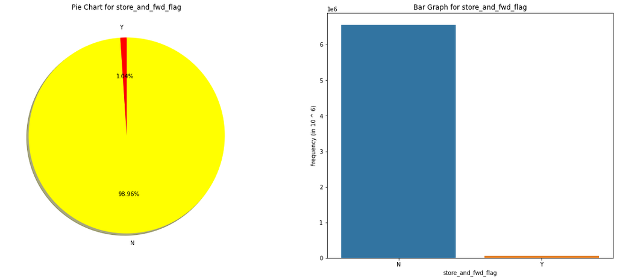

```python
# Frequency Distribution of store_and_fwd_flag :

values = df['store_and_fwd_flag'].value_counts().index
frequencies = df['store_and_fwd_flag'].value_counts().values

# Plotting a PieChart for the store_and_fwd_flag :
fig = plt.figure(figsize = (20,8))
fig.add_subplot(1,2,1)
plt.title('Pie Chart for store_and_fwd_flag')
colors = ['yellow','red']
labels = ['N', 'Y']
plt.pie(frequencies, colors = colors, labels = labels, autopct = '%.2f%%', counterclock = False, startangle = 90, shadow = True)

# Plotting a BarGraph for the store_and_fwd_flag :
fig.add_subplot(1,2,2)
plt.title('Bar Graph for store_and_fwd_flag')
sns.barplot(values, frequencies)
plt.xlabel("store_and_fwd_flag")
plt.ylabel("Frequency (in 10 ^ 6)")

plt.show()
```

**OBSERVATIONS :**

- *In **98.96% of the cases, the trip record was not held in the vehicle's memory** before sending it to the vendor, as the vehicle did not have a connection to the server.*
- *The proportion of the trips, with the **store_and_fwd_flag = 'Y' is very very less, just 1.04%**.*

#### **payment_type :**

```
Payment type : 1.0 (71.58%)
Payment type : 2.0 (27.94%)
Payment type : 3.0 (0.35%)
Payment type : 4.0 (0.13%)
Payment type : 5.0 (0.00%)
```

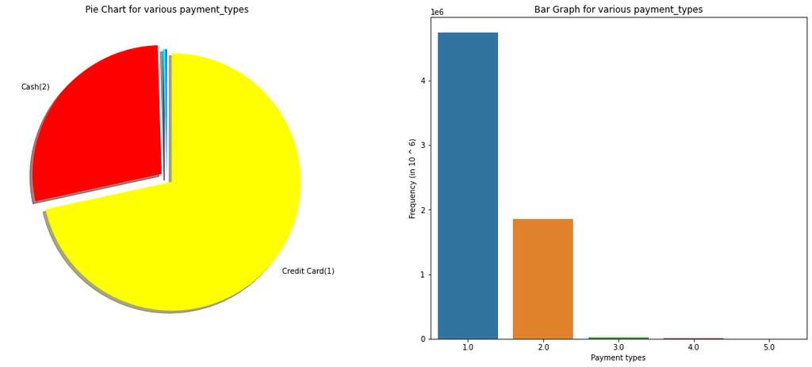

```python
# Frequency Distribution of payment_type :

values = df['payment_type'].value_counts().index
frequencies = df['payment_type'].value_counts().values

# Plotting a PieChart for the various payment_types :
fig = plt.figure(figsize = (20,8))
fig.add_subplot(1,2,1)
plt.title('Pie Chart for various payment_types')
colors = ['yellow','red', 'cyan', 'blue', 'violet']
explode = [0.05, 0.05, 0, 0, 0]
labels = ['Credit Card(1)','Cash(2)','','','']
plt.pie(frequencies, colors = colors, labels = labels, explode = explode, counterclock = False, startangle = 90, shadow = True)

# Plotting a BarGraph for the various payment_types :
fig.add_subplot(1,2,2)
plt.title('Bar Graph for various payment_types')
sns.barplot(values, frequencies)
plt.xlabel("Payment types")
plt.ylabel("Frequency (in 10 ^ 6)")

# Percentage Share of each possible value of payment_type(IN DESCENDING ORDER & UPTO 2 decimal places) :
total = sum(frequencies)
for i in range(len(values)):
  print("Payment type :", values[i], '(' + '%.2f'%((frequencies[i]/total)*100) + '%)' )

print('\n\n')
plt.show()
```

**OBSERVATIONS :**

- *Credit Card seems to be the most commonly used transaction means in New York as **71.58% of the trips are paid via Credit Cards**.*
- *Cash seems to be the second most commonly used transaction means as **27.94% of the trips are paid via Cash**.*
- *The proprtion of the trips with **payment_type other than 1(Credit Card) and 2(Cash) is very very less, just 0.48**.*

#### **trip_distance :**

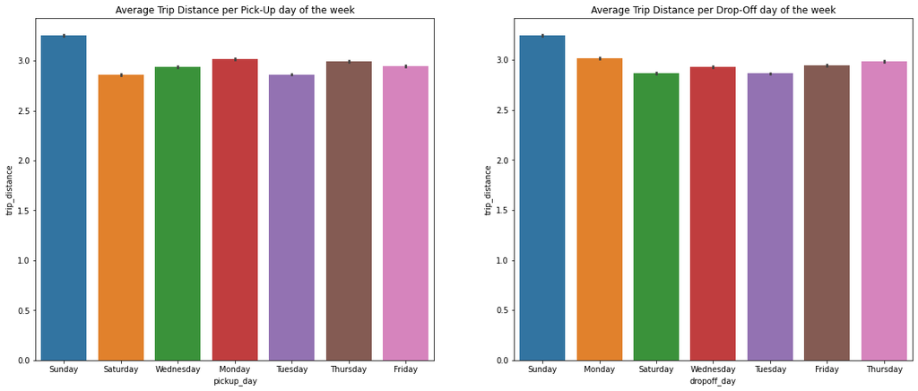

```python
# Analyzing and Visualizing the relationship between 'trip_distance' and the 'days of the week'.

fig, ax = plt.subplots(nrows = 1, ncols = 2, figsize = (20, 8))

ax[0].set_title('Average Trip Distance per Pick-Up day of the week')
sns.barplot(x = 'pickup_day', y = 'trip_distance', data = df, ax = ax[0])

ax[1].set_title('Average Trip Distance per Drop-Off day of the week')
sns.barplot(x = 'dropoff_day', y = 'trip_distance', data = df, ax = ax[1])

plt.show()
```

**OBSERVATIONS :**

- *The **average trip_distance is maximum for Sundays, So we can assume that long trips are made during Sundays(As Sunday is a holiday)**. Similar to what one expects.*
- *There **doesn't seem to be much significant difference in the average trip_distance for the rest of the 6 days**. **All the bars seem to be of somewhat similar height only**.*

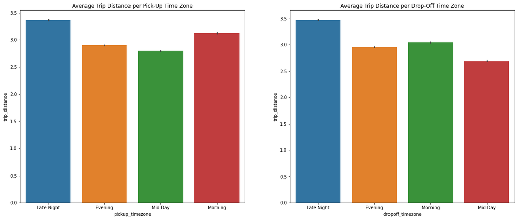

```python
# Analyzing and Visualizing the relationship between 'trip_distance' and the 'timezones'.

fig, ax = plt.subplots(nrows = 1, ncols = 2, figsize = (20, 8))

ax[0].set_title('Average Trip Distance per Pick-Up Time Zone')
sns.barplot(x = 'pickup_timezone', y = 'trip_distance', data = df, ax = ax[0])

ax[1].set_title('Average Trip Distance per Drop-Off Time Zone')
sns.barplot(x = 'dropoff_timezone', y = 'trip_distance', data = df, ax = ax[1])

plt.show()
```

**OBSERVATIONS :**

- *The **average trip_distance is maximum at Late Nights and Mornings and least/minimum at Mid Days and Evenings**. So, We can come up with a **hypothesis that long trips are made during Late Nights (22 - 04 hours)/(10:00 PM to 4:00 A.M) and Mornings (04 - 10 hours)/(4:00 AM to 10:00 AM) because of the fact that the traffic would be very less during these time zones and one would be able to reach his/her destination during the earlier part of the day**. This seems to be very much similar to our nation as well as we also prefer long duration trips at Late Nights and Early Mornings.*
- *There **doesn't seem to be much significant difference in the average trip_distance at Evenings and Mid Days, as the bars are of almost the same height**.*

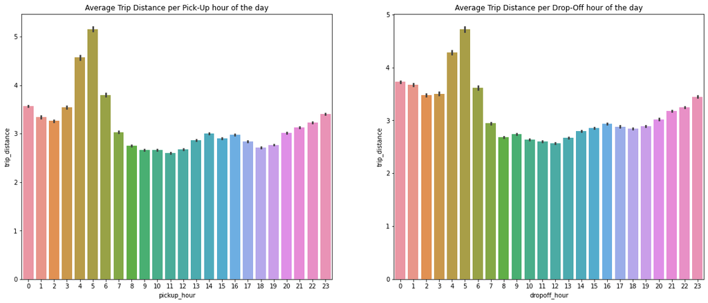

```python
# Analyzing and Visualizing the relationship between 'trip_distance' and the 'hours of the day'.

fig, ax = plt.subplots(nrows = 1, ncols = 2, figsize = (20, 8))

ax[0].set_title('Average Trip Distance per Pick-Up hour of the day')
sns.barplot(x = 'pickup_hour', y = 'trip_distance', data = df, ax = ax[0])

ax[1].set_title('Average Trip Distance per Drop-Off hour of the day')
sns.barplot(x = 'dropoff_hour', y = 'trip_distance', data = df, ax = ax[1])

plt.show()
```

The above plot seems to be in accordance with the plot **Average Trip Distance per Time Zone**.

**OBSERVATIONS :**

- *The **average trip_distances are a bit large around (21 - 06 hours)/(9:00 PM to 6:00 AM), this again proves the fact that the long distance trips are made during Late Nights (22 - 04 hours)/(10:00 PM to 4:00 AM) and Early Mornings(05 - 06 hours)/(5:00 AM to 6:00 AM)**.*
- *There **doesn't seem to be much significant difference in the average trip_distance at Mid Days(10 - 16 hours)/(10:00 AM to 4:00 PM) and Evenings(16 - 22 hours)/(4:00 PM to 10:00 PM)**.*

#### **total_amount :**

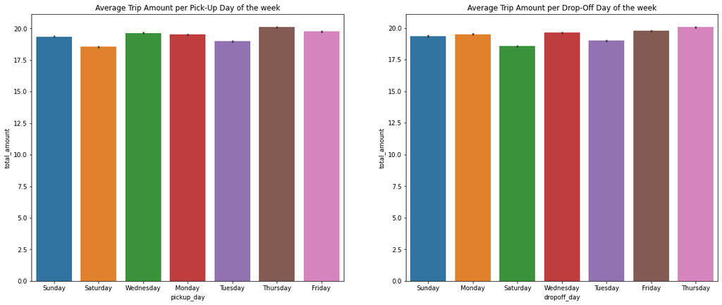

```python
# Analyzing and Visualizing the relationship between 'total_amount' and the 'days of the week'.

fig, ax = plt.subplots(nrows = 1, ncols = 2, figsize = (20, 8))

ax[0].set_title('Average Trip Amount per Pick-Up Day of the week')
sns.barplot(x = 'pickup_day', y = 'total_amount', data = df, ax = ax[0])

ax[1].set_title('Average Trip Amount per Drop-Off Day of the week')
sns.barplot(x = 'dropoff_day', y = 'total_amount', data = df, ax = ax[1])

plt.show()
```

**OBSERVATIONS :**

*There **doesn't seem to be any significant variation in the average total_amount with respect to the days of the week**. All the bars seem to be of somewhat similar height only.*

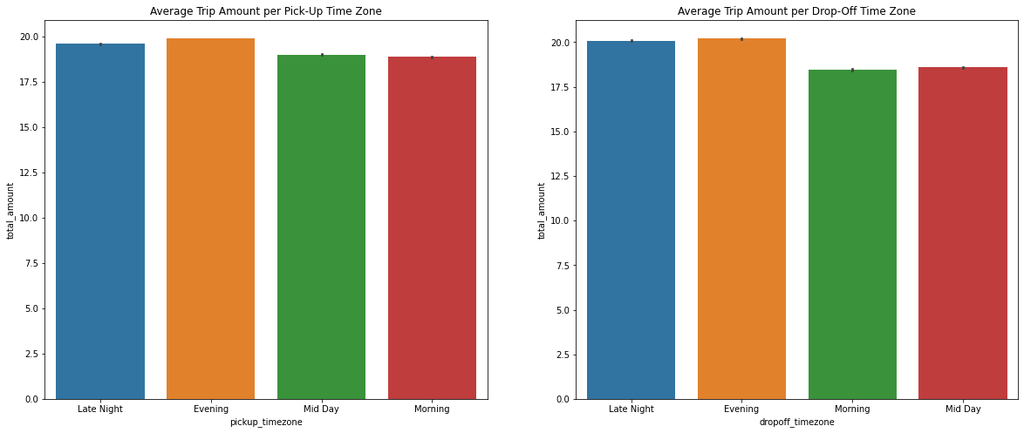

```python
# Analyzing and Visualizing the relationship between 'total_amount' and the 'TimeZone'.

fig, ax = plt.subplots(nrows = 1, ncols = 2, figsize = (20, 8))

ax[0].set_title('Average Trip Amount per Pick-Up Time Zone')
sns.barplot(x = 'pickup_timezone', y = 'total_amount', data = df, ax = ax[0])

ax[1].set_title('Average Trip Amount per Drop-Off Time Zone')
sns.barplot(x = 'dropoff_timezone', y = 'total_amount', data = df, ax = ax[1])

plt.show()
```

**OBSERVATIONS :**

*The **average trip_amount is greater at Evenings and Late Nights and lesser at Mid Days and Mornings**.*

*Very much similar to what one expects.*

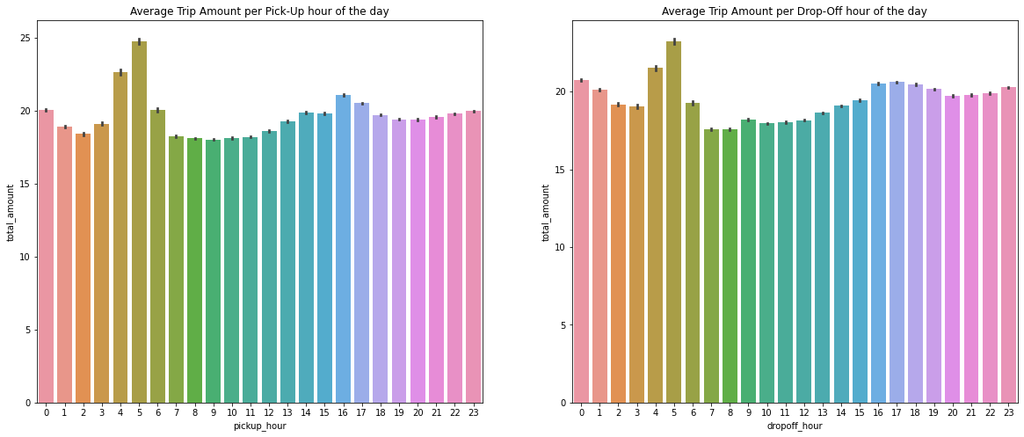

```python
# Analyzing and Visualizing the relationship between 'total_amount' and the 'hours of the day'.

fig, ax = plt.subplots(nrows = 1, ncols = 2, figsize = (20, 8))

ax[0].set_title('Average Trip Amount per Pick-Up hour of the day')
sns.barplot(x = 'pickup_hour', y = 'total_amount', data = df, ax = ax[0])

ax[1].set_title('Average Trip Amount per Drop-Off hour of the day')
sns.barplot(x = 'dropoff_hour', y = 'total_amount', data = df, ax = ax[1])

plt.show()
```

The above plot seems to be in accordance with the plot **Average Trip Amount per TimeZone**.

**OBSERVATIONS :**

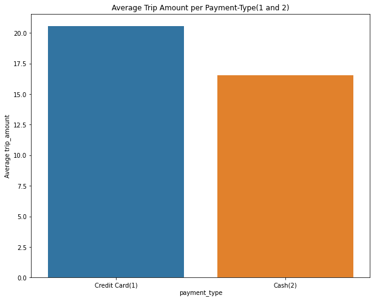

```python
# Analyzing and Visualizing the relationship between 'total_amount' and the 'payment_type'.
# Checking only for Credit Card(1) and Cash(2) :

fig, ax = plt.subplots(nrows = 1, ncols = 1, figsize = (10, 8))
values = ['Credit Card(1)', 'Cash(2)']
frequencies = [df[df['payment_type'] == 1]['total_amount'].mean(), df[df['payment_type'] == 2]['total_amount'].mean()]

ax.set_title('Average Trip Amount per Payment-Type(1 and 2)')
ax.set_xlabel('payment_type')
ax.set_ylabel('Average trip_amount')
sns.barplot(values, frequencies, ax = ax)

plt.show()
```

**OBSERVATIONS :**

*The **average trip_amount for Credit Card payments is greater than the average_trip amount for Cash payments**. So, We can come up with a **hypothesis that for bigger payments mostly Credit Cards are used, and Cash is used for smaller payments**.*